# Lab 2

[Jillian Preece and Mackenzie O’Brien]

[September 20, 2017]

**Author:** [Jillian Preece]

**Discussants:** [Mackenzie O’Brien]

**Load CDC data:**

```r
source("http://foxweb.marist.edu/users/duy.nguyen2/cdc.R")
names(cdc)
```

```
## [1] "genhlth"  "exerany"  "hlthplan" "smoke100" "height"   "weight"
## [7] "wtdesire" "age"      "gender"
```

#### Exercise 1:

```r
head(cdc)
```

```
##     genhlth exerany hlthplan smoke100 height weight wtdesire age gender
## 1      good       0        1        0     70    175      175  77      m
## 2      good       0        1        1     64    125      115  33      f
## 3      good       1        1        1     60    105      105  49      f
## 4      good       1        1        0     66    132      124  42      f
## 5 very good       0        1        0     61    150      130  55      f
## 6 very good       1        1        0     64    114      114  55      f
```

```r
tail(cdc)
```

```
##         genhlth exerany hlthplan smoke100 height weight wtdesire age
## 19995      good       0        1        1     69    224      224  73
## 19996      good       1        1        0     66    215      140  23
## 19997 excellent       0        1        0     73    200      185  35
## 19998      poor       0        1        0     65    216      150  57
## 19999      good       1        1        0     67    165      165  81
## 20000      good       1        1        1     69    170      165  83
##       gender
## 19995      m
## 19996      f
## 19997      m
## 19998      f
## 19999      f
## 20000      m
```

```r
length(cdc)
```

```
## [1] 9
```

```r
summary(cdc$weight)
```

```
##    Min. 1st Qu.  Median    Mean 3rd Qu.    Max.
##    68.0   140.0   165.0   169.7   190.0   500.0
```

```r
190-140
```

```
## [1] 50
```

```r
mean(cdc$weight)
```

```
## [1] 169.683
```

```r
var(cdc$weight)
```

```
## [1] 1606.484
```

```r
median(cdc$weight)
```

```
## [1] 165
```

```r
table(cdc$smoke100)
```

```
##
##     0     1
## 10559  9441
```

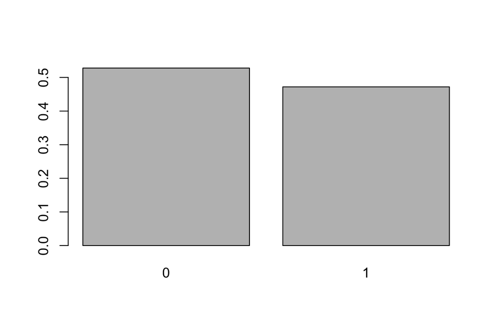

```r
smoke<-table(cdc$smoke100)/20000

barplot(smoke)
```

[There are nine variables: -genhlth: categorical -exerany: discrete -hlthplan: discrete -smoke100: discrete -height: discrete -weight: discrete -wtdesire: discrete -age: discrete -gender: categorical]

#### Exercise 2:

```r
table(cdc$gender,cdc$smoke100)
```

```
##
##        0    1
##   m 4547 5022
##   f 6012 4419
```

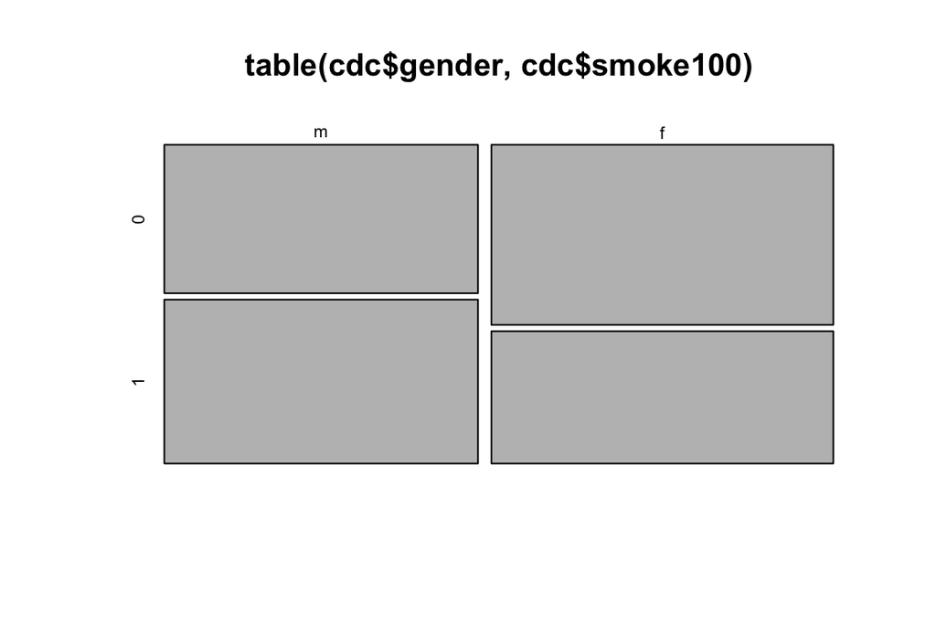

```r
mosaicplot(table(cdc$gender,cdc$smoke100))
```

```r
#summary of height
summary(cdc$height)
```

```
##    Min. 1st Qu.  Median    Mean 3rd Qu.    Max.
##   48.00   64.00   67.00   67.18   70.00   93.00
```

```r
#summary of age
summary(cdc$age)
```

```
##    Min. 1st Qu.  Median    Mean 3rd Qu.    Max.
##   18.00   31.00   43.00   45.07   57.00   99.00
```

```r
#relative frequency of gender
table(cdc$gender)/20000
```

```
##
##       m       f
## 0.47845 0.52155
```

```r
#relative frequency of exerany
table(cdc$exerany)/20000
```

```
##
##      0      1
## 0.2543 0.7457
```

```r
#how many males?
tapply(cdc$gender, cdc["gender"], length)
```

```
## gender
##     m     f
##  9569 10431
```

```r
#proportion reported in excellent health
table(cdc$genhlth=="excellent")/20000
```

```
##
##   FALSE    TRUE
## 0.76715 0.23285
```

[Interquartile Range of Height: 70-64=6 IQR of Age: 57-31=26]

#### Exercise 3:

```r
dim(cdc)
```

```
## [1] 20000     9
```

```r
cdc[567,6]
```

```
## [1] 160
```

```r
names(cdc)
```

```
## [1] "genhlth"  "exerany"  "hlthplan" "smoke100" "height"   "weight"
## [7] "wtdesire" "age"      "gender"
```

```r
cdc[1:10,6]
```

```
##  [1] 175 125 105 132 150 114 194 170 150 180
```

```r
1:10
```

```
##  [1]  1  2  3  4  5  6  7  8  9 10
```

```r
cdc[1:10,]
```

```
##      genhlth exerany hlthplan smoke100 height weight wtdesire age gender
## 1       good       0        1        0     70    175      175  77      m
## 2       good       0        1        1     64    125      115  33      f
## 3       good       1        1        1     60    105      105  49      f
## 4       good       1        1        0     66    132      124  42      f
## 5  very good       0        1        0     61    150      130  55      f
## 6  very good       1        1        0     64    114      114  55      f
## 7  very good       1        1        0     71    194      185  31      m
## 8  very good       0        1        0     67    170      160  45      m
## 9       good       0        1        1     65    150      130  27      f
## 10      good       1        1        0     70    180      170  44      m
```

```r
cdc[,6]
```

```
##     [1] 175 125 105 132 150 114 194 170 150 180 186 168 185 170 170 185 156
##    [18] 185 200 125 200 160 160 165 105 190 190 160 115 185 166 180 182 185
##    [35] 220 117 160 190 125 160 124 143 118 210 200 145 175 130 112 141 179
##    [52] 135 140 170 150 172 125 168 120 180 186 144 250 160 164 155 140 125
##    [69] 140 190 140 134 217 215 190 215 112 136 142 210 180 120 225 200 148
##    [86] 143 135 115 193 140 265 166 145 138 137 175 230 140 180 100 118 142
##   [103] 110 114 175 180 140 193 211 220 210 160 132 163 132 207 145 190 200
##   [120] 170 280 125 120 224 115 185 160 250 190 205 200 160 144 185 140 200
##   [137] 280 180 250 172 215 138 185 220 136 190 150 130 172 107 187 125 110
##   [154] 205 140 128 180 165 204  97 130 180 195 187 142 225 180 180 180 128
##   [171] 130 215 180 152 151 143 175 210 235 190 220  92 185 150 129 135 140
##   [188] 110 183 212 165 171 205 170 170 155 222 200 150 210 130 200 155 135
##   [205] 200 134 128 115 155 112 116 135 135 180 140 179 149 135 140 165 126
##   [222] 180 107 165 120 210 145 200 125 142 135 185 152 225 207 155 212 122
##   [239] 160 125 170 135 148 160 150 165 130 135 190 125 175 200 212 178 132
```

[output cut: 1162 more lines]

```r
cdc$weight
```

```
##     [1] 175 125 105 132 150 114 194 170 150 180 186 168 185 170 170 185 156
##    [18] 185 200 125 200 160 160 165 105 190 190 160 115 185 166 180 182 185
##    [35] 220 117 160 190 125 160 124 143 118 210 200 145 175 130 112 141 179
##    [52] 135 140 170 150 172 125 168 120 180 186 144 250 160 164 155 140 125
##    [69] 140 190 140 134 217 215 190 215 112 136 142 210 180 120 225 200 148
##    [86] 143 135 115 193 140 265 166 145 138 137 175 230 140 180 100 118 142
##   [103] 110 114 175 180 140 193 211 220 210 160 132 163 132 207 145 190 200
##   [120] 170 280 125 120 224 115 185 160 250 190 205 200 160 144 185 140 200
##   [137] 280 180 250 172 215 138 185 220 136 190 150 130 172 107 187 125 110
##   [154] 205 140 128 180 165 204  97 130 180 195 187 142 225 180 180 180 128
##   [171] 130 215 180 152 151 143 175 210 235 190 220  92 185 150 129 135 140
##   [188] 110 183 212 165 171 205 170 170 155 222 200 150 210 130 200 155 135
##   [205] 200 134 128 115 155 112 116 135 135 180 140 179 149 135 140 165 126
##   [222] 180 107 165 120 210 145 200 125 142 135 185 152 225 207 155 212 122
##   [239] 160 125 170 135 148 160 150 165 130 135 190 125 175 200 212 178 132
```

[output cut: 1162 more lines]

```r
cdc$weight[567]
```

```
## [1] 160
```

```r
cdc$weight[1:10]
```

```
##  [1] 175 125 105 132 150 114 194 170 150 180
```

[The mosaic plot shows that men are more likely to smoke than females, with about half of males reporting that they smoke. Approxiamtely 60% of females reported that they didn’t smoke.]

#### Exercise 4:

```r
cdc$gender == "m"
```

```
##     [1]  TRUE FALSE FALSE FALSE FALSE FALSE  TRUE  TRUE FALSE  TRUE  TRUE
##    [12]  TRUE  TRUE  TRUE  TRUE  TRUE  TRUE  TRUE  TRUE FALSE FALSE FALSE
##    [23]  TRUE  TRUE FALSE FALSE FALSE FALSE FALSE  TRUE  TRUE  TRUE  TRUE
##    [34]  TRUE FALSE FALSE FALSE  TRUE FALSE FALSE FALSE FALSE FALSE FALSE
##    [45] FALSE FALSE  TRUE FALSE FALSE  TRUE FALSE FALSE FALSE  TRUE  TRUE
##    [56]  TRUE FALSE FALSE FALSE FALSE  TRUE FALSE  TRUE FALSE  TRUE  TRUE
##    [67] FALSE FALSE FALSE  TRUE FALSE FALSE  TRUE  TRUE  TRUE  TRUE FALSE
##    [78]  TRUE FALSE  TRUE  TRUE  TRUE  TRUE  TRUE FALSE FALSE FALSE FALSE
##    [89] FALSE FALSE  TRUE FALSE FALSE FALSE  TRUE  TRUE  TRUE FALSE  TRUE
##   [100] FALSE FALSE  TRUE FALSE FALSE  TRUE  TRUE  TRUE  TRUE  TRUE  TRUE
##   [111]  TRUE  TRUE FALSE  TRUE FALSE  TRUE FALSE  TRUE FALSE  TRUE  TRUE
##   [122] FALSE FALSE FALSE FALSE  TRUE  TRUE FALSE  TRUE  TRUE  TRUE FALSE
##   [133] FALSE  TRUE FALSE FALSE  TRUE  TRUE  TRUE  TRUE  TRUE  TRUE  TRUE
##   [144]  TRUE FALSE FALSE  TRUE FALSE  TRUE FALSE  TRUE FALSE FALSE  TRUE
##   [155] FALSE FALSE  TRUE  TRUE  TRUE FALSE FALSE FALSE  TRUE  TRUE FALSE
```

[output cut: 1804 more lines]

```r
cdc$age>30
```

```
##     [1]  TRUE  TRUE  TRUE  TRUE  TRUE  TRUE  TRUE  TRUE FALSE  TRUE  TRUE
##    [12]  TRUE FALSE  TRUE FALSE  TRUE  TRUE  TRUE  TRUE  TRUE  TRUE  TRUE
##    [23]  TRUE FALSE FALSE  TRUE  TRUE  TRUE  TRUE  TRUE  TRUE  TRUE  TRUE
##    [34]  TRUE  TRUE  TRUE FALSE  TRUE FALSE FALSE  TRUE  TRUE  TRUE  TRUE
##    [45]  TRUE  TRUE  TRUE  TRUE  TRUE  TRUE  TRUE FALSE  TRUE FALSE  TRUE
##    [56]  TRUE  TRUE  TRUE  TRUE  TRUE  TRUE FALSE  TRUE  TRUE  TRUE  TRUE
##    [67]  TRUE  TRUE FALSE  TRUE FALSE  TRUE FALSE FALSE  TRUE  TRUE  TRUE
##    [78]  TRUE  TRUE  TRUE  TRUE FALSE  TRUE  TRUE  TRUE FALSE  TRUE FALSE
##    [89]  TRUE  TRUE  TRUE  TRUE  TRUE  TRUE  TRUE FALSE  TRUE  TRUE  TRUE
##   [100] FALSE  TRUE FALSE FALSE  TRUE  TRUE  TRUE FALSE  TRUE  TRUE FALSE
##   [111] FALSE  TRUE  TRUE  TRUE  TRUE  TRUE  TRUE  TRUE  TRUE FALSE FALSE
##   [122] FALSE  TRUE  TRUE  TRUE  TRUE  TRUE FALSE  TRUE  TRUE  TRUE  TRUE
##   [133] FALSE  TRUE  TRUE  TRUE  TRUE  TRUE  TRUE  TRUE  TRUE FALSE  TRUE
##   [144]  TRUE  TRUE  TRUE  TRUE  TRUE  TRUE FALSE  TRUE  TRUE  TRUE  TRUE
##   [155]  TRUE  TRUE  TRUE  TRUE  TRUE  TRUE FALSE FALSE  TRUE  TRUE  TRUE
```

[output cut: 1804 more lines]

```r
mdata<- subset(cdc, cdc$gender == "m")
head(mdata)
```

```
##      genhlth exerany hlthplan smoke100 height weight wtdesire age gender
## 1       good       0        1        0     70    175      175  77      m
## 7  very good       1        1        0     71    194      185  31      m
## 8  very good       0        1        0     67    170      160  45      m
## 10      good       1        1        0     70    180      170  44      m
## 11 excellent       1        1        1     69    186      175  46      m
## 12      fair       1        1        1     69    168      148  62      m
```

```r
m_and_over30 <-subset(cdc, gender =="m" & age>30)
m_or_over30<- subset(cdc, gender =="m" | age>30)

under23_and_smoke=subset(cdc, cdc$age<23 & cdc$smoke100==1)
head(under23_and_smoke)
```

```
##       genhlth exerany hlthplan smoke100 height weight wtdesire age gender
## 13  excellent       1        0        1     66    185      220  21      m
## 37  very good       1        0        1     70    160      140  18      f
## 96  excellent       1        1        1     74    175      200  22      m
## 180      good       1        1        1     64    190      140  20      f
## 182 very good       1        1        1     62     92       92  21      f
## 240 very good       1        0        1     64    125      115  22      f
```

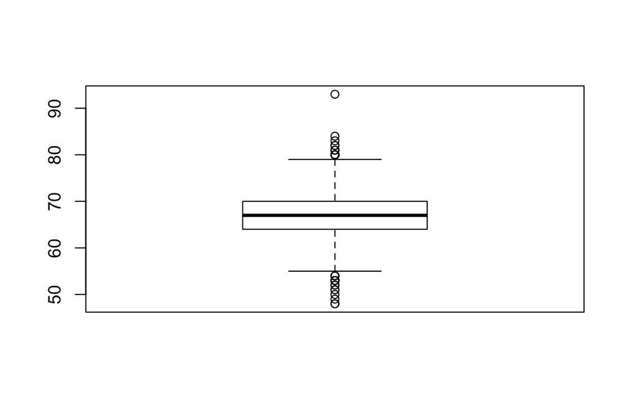

```r
boxplot(cdc$height)
```

```r
summary(cdc$height)
```

```
##    Min. 1st Qu.  Median    Mean 3rd Qu.    Max.
##   48.00   64.00   67.00   67.18   70.00   93.00
```

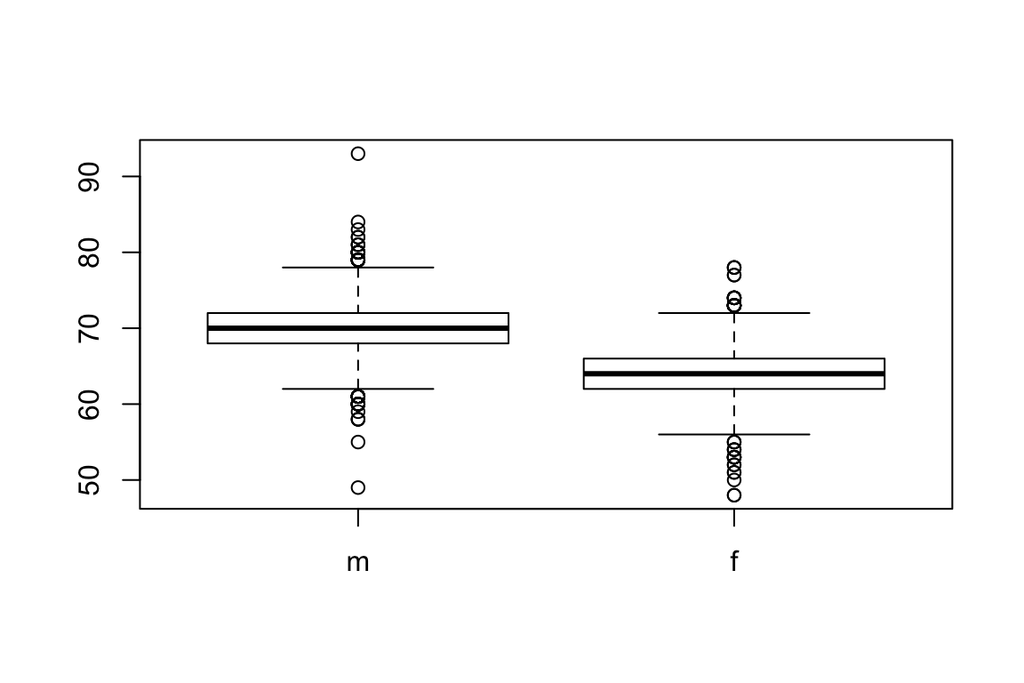

```r
boxplot(cdc$height~cdc$gender)
```

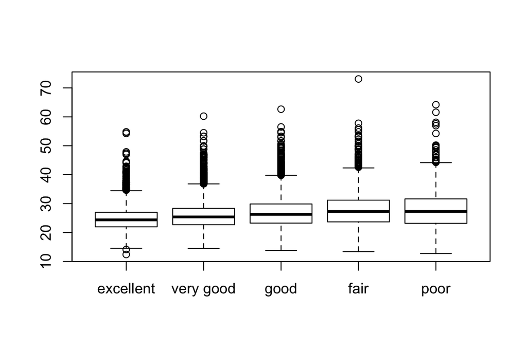

```r
bmi<-(cdc$weight / cdc$height^2)*703
boxplot(bmi~cdc$genhlth)
```

#### Exercise 5:

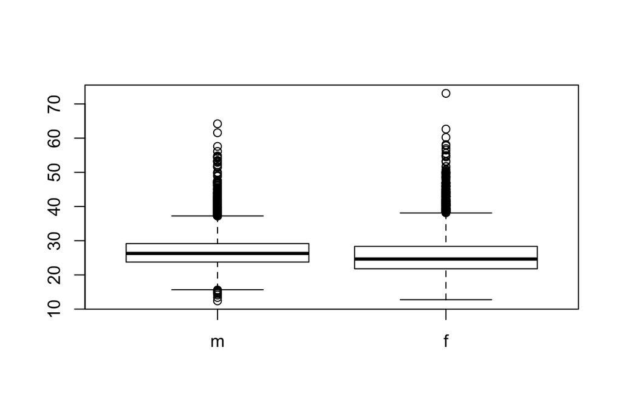

```r
boxplot(bmi~cdc$gender)
```

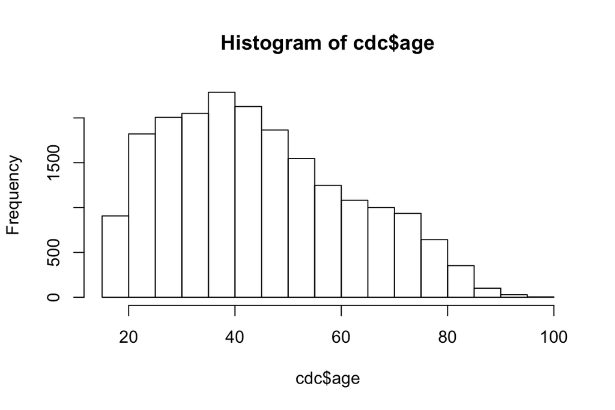

```r
hist(cdc$age)
```

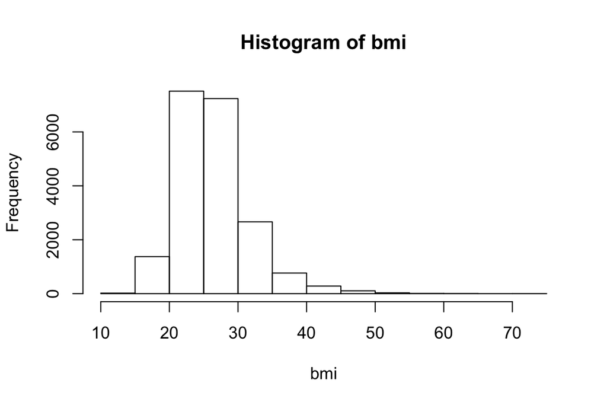

```r
hist(bmi)
```

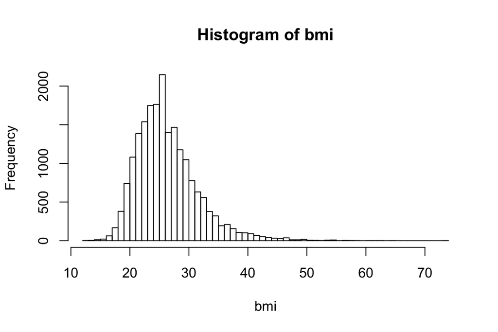

```r
hist(bmi,breaks=50)
```

```r
cdc$exerany_cat = NA
cdc$exerany_cat[cdc$exerany == 1] = "exercised"
cdc$exerany_cat[cdc$exerany == 0] = "didn't exercise"
cdc$exerany_cat = as.factor(cdc$exerany_cat)
```

[The first boxplotshows that as health got poorer, BMI increased.

We chose gender as the second variable, and that boxplot shows that while males and females have similar BMIs, the males had high and low outliers, while females only had high outliers.]

#### Exercise 6:

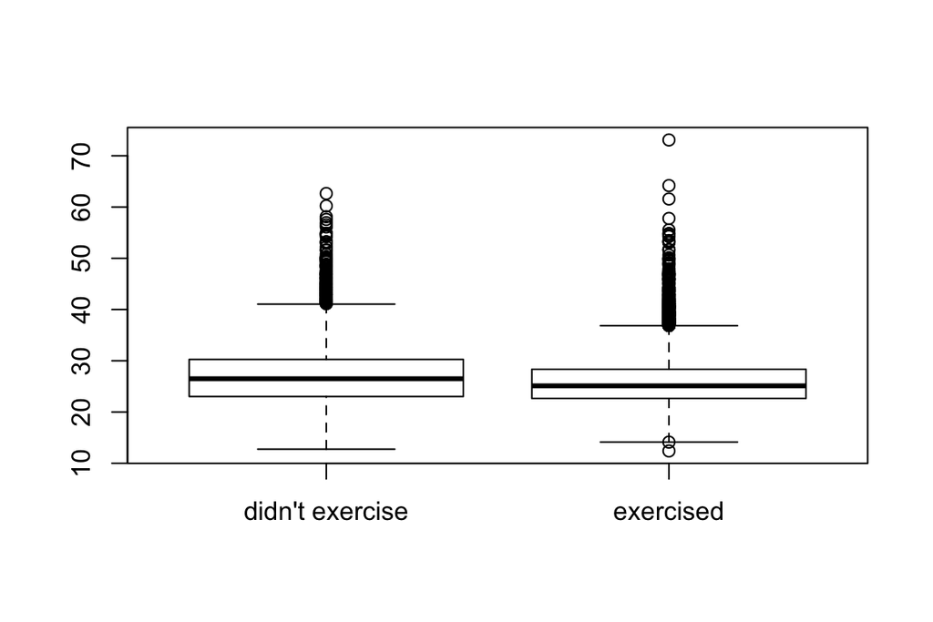

```r
boxplot(bmi~cdc$exerany_cat)
```

#### Exercise 7:

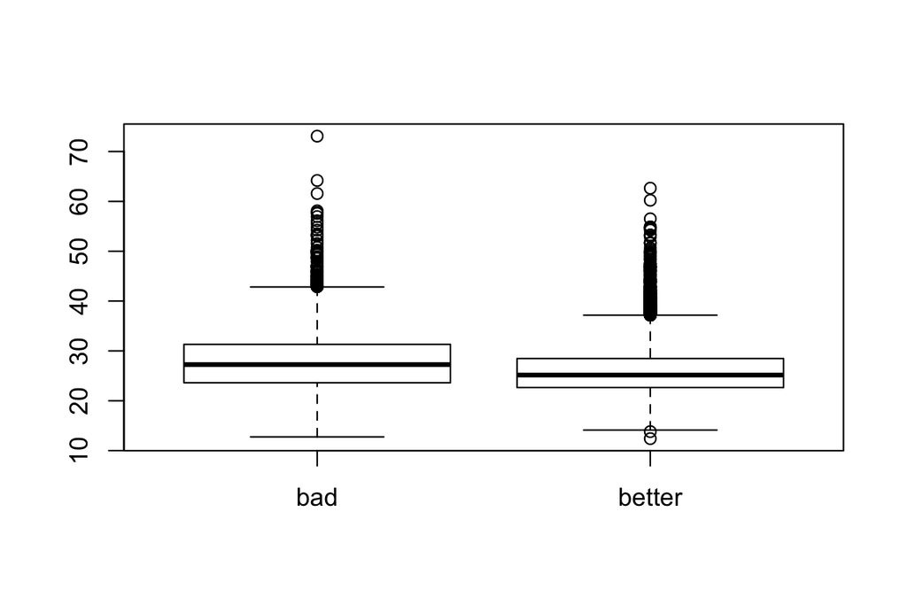

```r
cdc$genhlth_twolevs = NA  # create new variable, and fill it in with NAs first
cdc$genhlth_twolevs[cdc$genhlth %in% c("fair", "poor")] = "bad"
cdc$genhlth_twolevs[cdc$genhlth %in% c("good", "very good", "excellent")] = "better"
cdc$genhlth_twolevs = as.factor(cdc$genhlth_twolevs)  # save new variable as factor

boxplot(bmi~cdc$genhlth_twolevs)
```

#### Exercise 8:

```r
median_height = median(cdc$height)
cdc$height_cat = NA  # create new variable, and fill it in with NAs first
cdc$height_cat[cdc$height < median_height] = "below median"
cdc$height_cat[cdc$height >= median_height] = "at or above median"
cdc$height_cat = as.factor(cdc$height_cat)  # save new variable as factor
table(cdc$height_cat)
```

```
##
## at or above median       below median
##              10800               9200
```

```r
cdc$height_cat = factor(cdc$height_cat, levels = c("below median", "at or above median"))

table(cdc$height_cat)
```

```
##
##       below median at or above median
##               9200              10800
```

**Load class survey data:**

```r
surveyS15 = read.csv("http://foxweb.marist.edu/users/duy.nguyen2/surveyS15.csv")
head(surveyS15)
```

```
##   pets   us_region class_year hair_color  campus         watch_sports
## 1    1  California  Sophomore      Brown Central                Other
## 2    1 New England  Sophomore      Brown    West I don't watch sports
## 3    1   Southeast  Sophomore     Blonde    West           Basketball
## 4    1     Midwest  Sophomore     Blonde Central                Other
## 5    1   Southeast First-year      Brown    East           Basketball
## 6    3   Southeast First-year      Brown    East           Basketball
##   beyonce_love    fav_artist social_network relationship_status
## 1          meh  Taylor swift         Yikyak    it's complicated
## 2     hell yes none of these      Instagram                  no
## 3          yes none of these       Facebook    it's complicated
## 4     hell yes  Taylor swift       Snapchat                  no
## 5     hell yes none of these       Snapchat    it's complicated
## 6          meh none of these      Instagram                 yes
##   num_siblings num_languages nights_drinking      pbj_or_n tenting
```

[output cut: 90 more lines]

```r
names(surveyS15)
```

```
##  [1] "pets"                      "us_region"
##  [3] "class_year"                "hair_color"
##  [5] "campus"                    "watch_sports"
##  [7] "beyonce_love"              "fav_artist"
##  [9] "social_network"            "relationship_status"
## [11] "num_siblings"              "num_languages"
## [13] "nights_drinking"           "pbj_or_n"
## [15] "tenting"                   "countries_visited"
## [17] "first_kiss"                "hours_watching_television"
## [19] "perimeter"                 "fav_campus_eatery"
## [21] "fb_visits_per_day"         "ac"
## [23] "condiment"                 "vegetarian"
## [25] "voted_for_president"       "social_club"
## [27] "space_time"                "university_applications"
## [29] "pizza_consumption"         "sick"
## [31] "games_attended"            "pepsi_or_coke"
## [33] "fav_friend_character"      "continents_visited"
## [35] "game_of_thrones"           "netflix_binge_show"
## [37] "chipotle_order"            "fav_pokemon"
## [39] "first_tooth"               "fav_cheese"
## [41] "cat_or_dog"                "fav_late_night_food"
## [43] "fav_dessert_flavor"        "fav_off_campus_restaurant"
## [45] "vending_machine"           "multicultural"
## [47] "smell"                     "parents_age"
## [49] "marketplace_worst_meal"    "best_book_turned_show"
## [51] "fav_fantasy_universe"      "hogwarts_house"
## [53] "shooters"
```

### On your own:

#### 1:

```r
summary(surveyS15$fav_cheese)
```

```
##              Blue              Brie           Cheddar              Feta
##                 4                32                28                13
##              Goat None of the above        Pepperjack
##                20                33                22
```

```r
summary(surveyS15$parents_age)
```

```
##    Min. 1st Qu.  Median    Mean 3rd Qu.    Max.    NA's
##    2.00   50.00   52.00   52.05   55.00   67.00       3
```

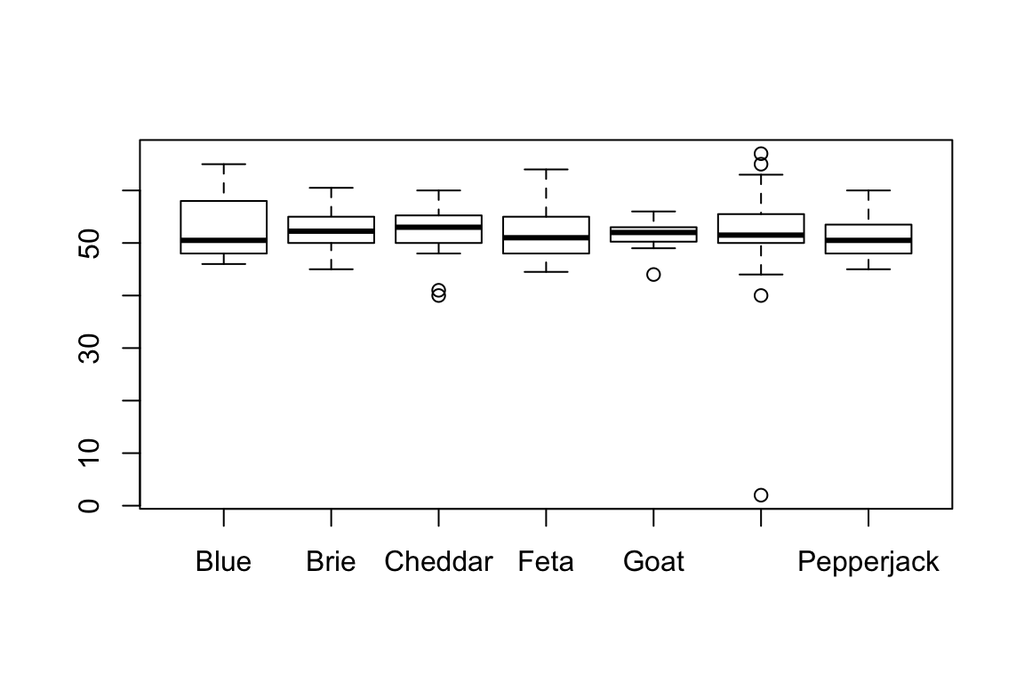

```r
boxplot(surveyS15$parents_age~surveyS15$fav_cheese)
```

```r
youngparents = subset(surveyS15, surveyS15$parents_age<30)
oldparents = subset(surveyS15, surveyS15$parents_age>=30)
```

#### 2:

```r
summary(surveyS15$hogwarts_house)
```

```
##          Gryffindor (because I'm a badass)
##                                         62
## Hufflepuff (because I'm good at something)
##                                         24
##    Ravenclaw (because I'm better than you)
##                                         47
##           Slytherin (because I'll cut you)
##                                         16
##                                       NA's
##                                          3
```

```r
summary(surveyS15$pepsi_or_coke)
```

```
##                  Coke Neither they're nasty         No preference
##                    91                    40                     9
##                 Pepsi
##                    12
```

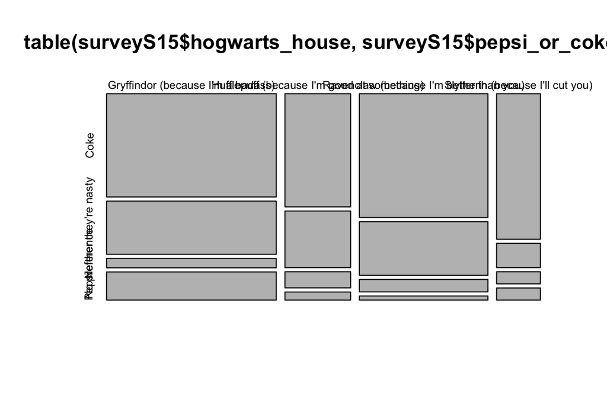

```r
mosaicplot(table(surveyS15$hogwarts_house,surveyS15$pepsi_or_coke))
```

#### 3:

[Statistical operations such as mean, median, and other summary functions were covered in the textbook and in class, as well as subset, transform, and attach. However, we have yet to cover detach or within. Other functions covered include the probability/distribution functions such as pnorm and pbinom and the other similar functions. We have not yet covered the curve function or qq plots. Overall, we are following the textbook pretty thoroughly in our class lectures and labs. ]